# Prétraitement et visualisation

AMOUROUX Jan RODRIGUES Camille-Astrid BRAHIMI Celia

2025-04-26

# Importation des librairies

```r
library(plotly); library(magrittr); library(factoextra); library(tidyverse);  library(GGally); library(stringr); library(Hmisc)
```

# Chargement des données

```r
OutCatdata = read.csv("../data/OutCatdata.csv", stringsAsFactors = T, na.strings = '')
OutCatdataQuanti = read.csv("../data/OutCatdataQuantitativ.csv", stringsAsFactors = F, na.strings = '')
```

# Analyse des données au format qualitatif

## Prévisualisation des données (déjà présnent dans DataAnalysisCats ne sera donc pas exécuter ici)

```r
# Résumé des informations du fichier
summary(OutCatdata)

# Visualisation du caractère de chasse des chats
OutCatdata %>%
  group_by(Hunt, animal.id)%>%
  count(animal.id)

# Visualisation du nombre de chats dans chaque classe
NonHunter = 0 ; Hunter = 0 ; Unknown = 0
CatList = unique(OutCatdata$animal.id)
for (i in CatList){
  line = which(OutCatdata$animal.id ==i )
  foo = OutCatdata[line[1],]$Hunt
  if (foo == "No")
    NonHunter = NonHunter +1
  if (foo == "Yes")
    Hunter = Hunter +1
  if (foo == "NA")
    Unknown = Unknown +1
}
cat("Nombre de chats : non chasseur", NonHunter, "chasseur", Hunter, "inconnu", Unknown)
cat("Pour un total de", NonHunter+Hunter+Unknown, "chats.")

# Nombre de chats dans le fichier
length(unique(OutCatdata$animal.id))
```

## Visualisation à l’aide de graphique

### Epurer les données

Nous allons dans un premier temps chercher à rendre le plus de données possible qualitative.

Suppression des colonnes 1 jusqu’à 5, soit : `"event.id"`, `"timestamp"`, `"location.long"`, `"location.lat"` sachant que la première est juste un comteur du nombre de ligne

```r
CatDataquali = OutCatdata[,-1:-5]
CatDataquali = (CatDataquali[,-10:-13])
```

### Convertir les *int* en facteurs

Toujours dans l’optique d’avoir le plus de variable qualitatives.

```r
CatDataquali$N.pray = as.factor(CatDataquali$N.pray) ;
CatDataquali$N.neigbours = as.factor(OutCatdata$N.neigbours)
```

```r
CatDataquali$Hrs.indors = as.numeric(CatDataquali$Hrs.indors)
order = sprintf("%02d", -1:24)
CatDataquali$Hrs.indors = order[ CatDataquali$Hrs.indors ] %>% as.factor
```

On a des variables avec beaucoup de niveaux (nom, dates) nous allons les retirer car cela ralentit le temps de calcul et va générer des règles trop spécifiques (le nom surtout)

```r
trimmedCatDataquali = CatDataquali[,-1] #supprme l'indice de ligne
trimmedCatDataquali = trimmedCatDataquali[,-1] # suppression de la date de début
names(trimmedCatDataquali)
```

```
## [1] "animal.life.stage"             "animal.reproductive.condition"
## [3] "animal.sex"                    "Hunt"
## [5] "N.pray"                        "Hrs.indors"
## [7] "N.neigbours"
```

nous avons un tableau avec les variables :

`"animal.life.stage"`, `"animal.reproductive.condition"`, `"animal.sex"`, `"Hunt"`, `"N.pray"`, `"Hrs.indors"`, `"N.neigbours"`

### Application du TP

#### 1 exemple avec N.pray pour prédire Hunt

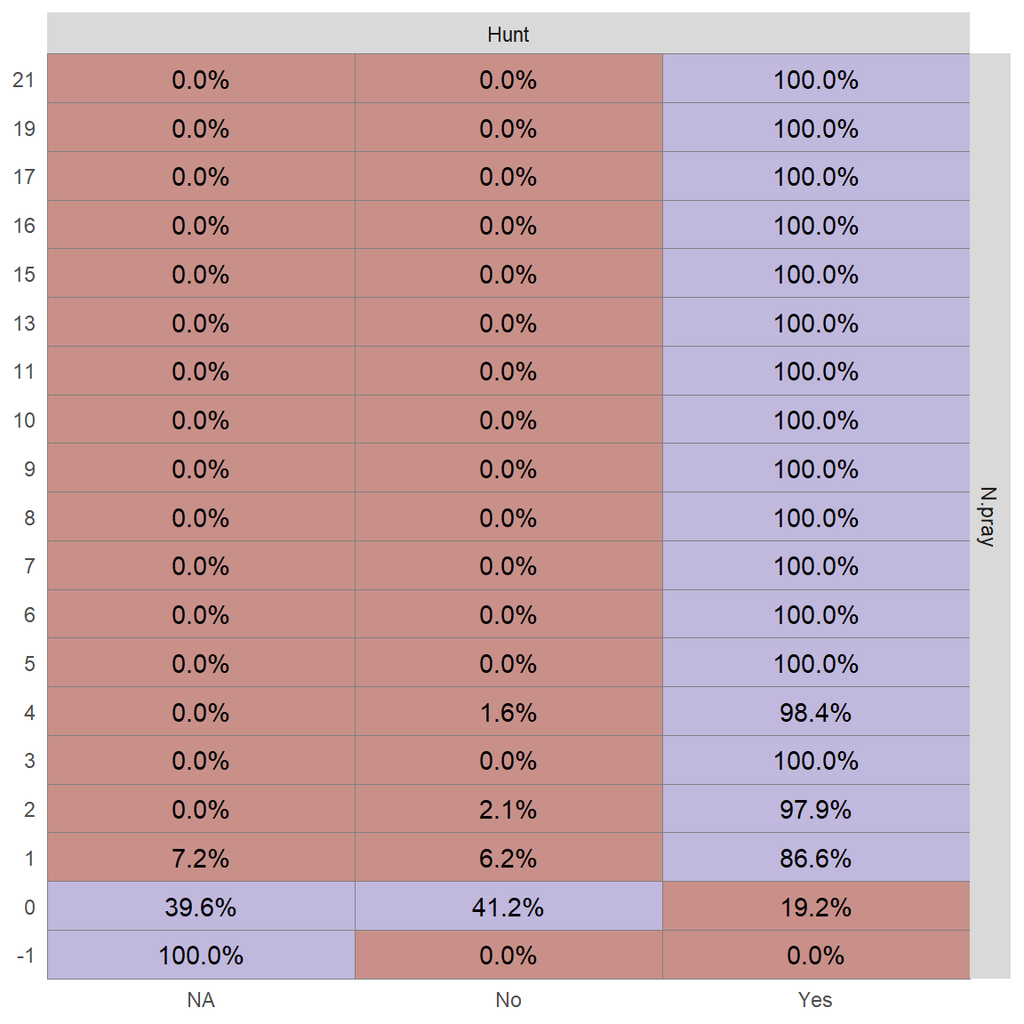

```r
CatDataquali %>%
  ggtable('Hunt','N.pray',
          cells = 'row.prop', fill = "std.resid",
          cardinality_threshold=NULL)
```

Première visualisation du comportement de chasse en fonction du nombre de proie.

*cardinality_threshold* : est un paramètre de sécurité mais il nous faut la retirer car on a de multiple modalités pour nos variables

#### Toutes les variables pour prédire Hunt

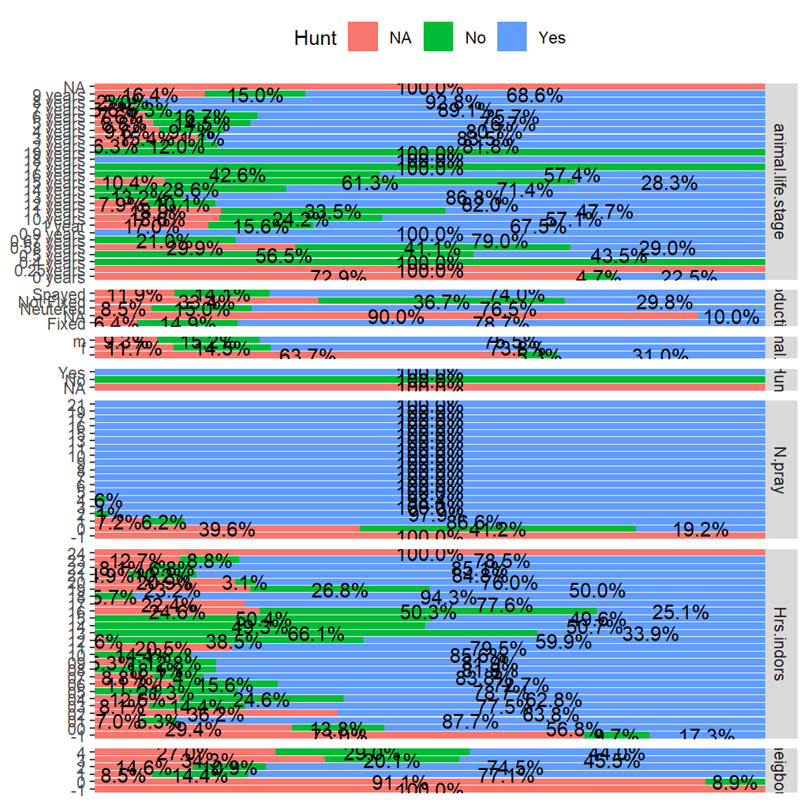

```r
trimmedCatDataquali %>% ggbivariate(outcome = "Hunt",
                             explanatory = colnames(trimmedCatDataquali),
                              cardinality_threshold=NULL)
```

#### Visualisation des différentes variables

stockage de Hunt dans `classes` et le tableau variables dans `Vars`

```r
classes = trimmedCatDataquali$Hunt

Vars = trimmedCatDataquali%>% select(-Hunt)
```

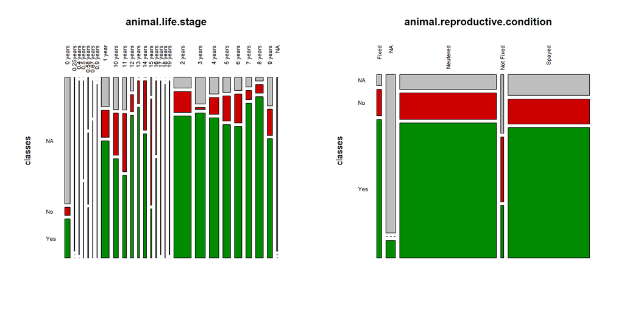

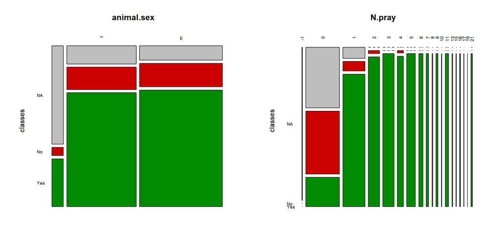

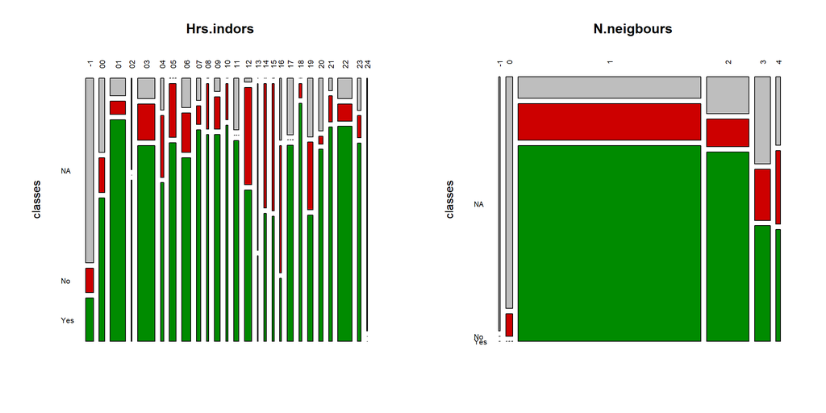

```r
par(mfrow = c(1,2))
foo=sapply(colnames(Vars),
           function(a)
             plot(
               table(unlist(Vars[,a]), classes),
               main=a, las = 2,
               col = c("gray","red3","green4")
               )
           )
```

# Analyse des données au format quantitatif

## Prévisualisation des données

## Visualisation à l’aide de graphique

### Mettre toutes les données au format num ou int

```r
OutCatdataQuanti$N.pray = as.numeric(OutCatdataQuanti$N.pray)
OutCatdataQuanti$Hrs.indors = as.numeric(OutCatdataQuanti$Hrs.indors)
OutCatdataQuanti$N.neigbours = as.numeric(OutCatdataQuanti$N.neigbours)
```

### Epurer les données

```r
CatDataquanti = OutCatdataQuanti[,-1:-3]
CatDataquanti$StartDate = as.Date(CatDataquanti$StartDate)
CatDataquanti$EndDate = as.Date(CatDataquanti$EndDate)
```

Retirer le nom car cela ralentit le temps de calcul et va génerer des règles trop spécifiques.

```r
trimmedCatDataquanti = CatDataquanti[,-3]
```

### Première visualisation du comportement de chasse en fonction du nombre de proie.

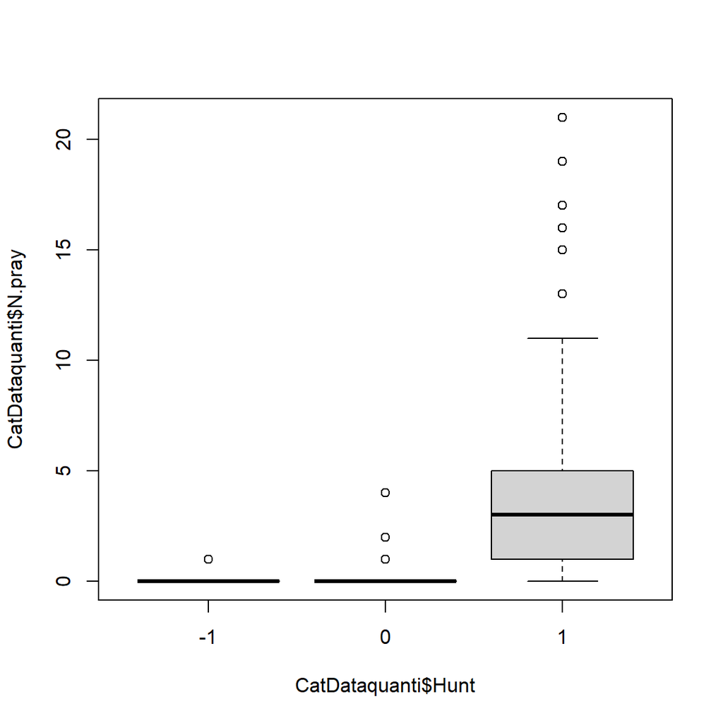

```r
boxplot(CatDataquanti$N.pray~CatDataquanti$Hunt)
```

Les dates de début et de fin ont un impact trop fort sur le jeu de données. On va tenter de les conserver en ne notant que le mois des dates.

```r
trimmedCatDataquanti = CatDataquanti
trimmedCatDataquanti$StartDate = as.Date(as.character(trimmedCatDataquanti$StartDate), format = "%Y-%m-%d")
trimmedCatDataquanti$EndDate = as.Date(as.character(trimmedCatDataquanti$EndDate), format = "%Y-%m-%d")

trimmedCatDataquanti$StartDate = as.numeric(format((trimmedCatDataquanti$StartDate), "%m"))
trimmedCatDataquanti$EndDate = as.numeric(format((trimmedCatDataquanti$EndDate), "%m"))
```

Les heures de début et de fin ont maintenant un impact trop fort sur le jeu de données. On va tenter de les conserver en ne notant que l’heure de sortie.

```r
trimmedCatDataquanti$StartHours = strptime(trimmedCatDataquanti$StartHours, format = "%H:%M:%S")
trimmedCatDataquanti$StartHours = as.numeric(format((trimmedCatDataquanti$StartHours), "%H"))

trimmedCatDataquanti$EndHours = strptime(trimmedCatDataquanti$EndHours, format = "%H:%M:%S")
trimmedCatDataquanti$EndHours = as.numeric(format((trimmedCatDataquanti$EndHours), "%H"))
```

Retirer les noms et modifier la colonne animal.reproductive.condition

```r
trimmedCatDataquanti = trimmedCatDataquanti[,-3]
fooList = colnames(trimmedCatDataquanti)
fooList[3] = 'sterilization'
colnames(trimmedCatDataquanti) = fooList
```

Réafficher le boxplot

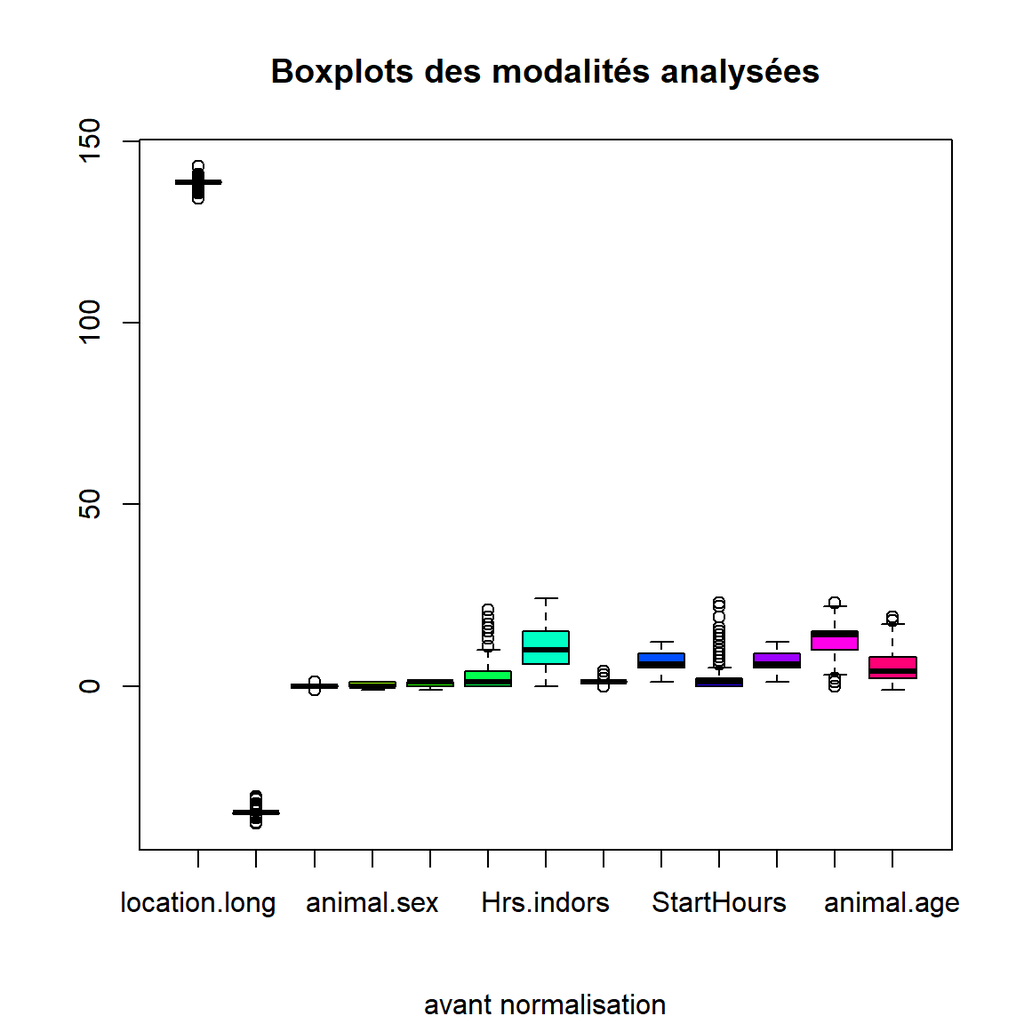

```r
boxplot(trimmedCatDataquanti, col = rainbow(length(trimmedCatDataquanti)))
title(main = "Boxplots des modalités analysées", sub = "avant normalisation")
```

On observe qu’il faut normaliser les données avant de poursuivre les analyses.

```r
str(trimmedCatDataquanti)
```

```
## 'data.frame':    1057320 obs. of  13 variables:
##  $ location.long: num  139 139 139 139 139 ...
##  $ location.lat : num  -35 -35 -35 -35 -35 ...
##  $ sterilization: int  0 0 0 0 0 0 0 0 0 0 ...
##  $ animal.sex   : int  1 1 1 1 1 1 1 1 1 1 ...
##  $ Hunt         : int  1 1 1 1 1 1 1 1 1 1 ...
##  $ N.pray       : num  6 6 6 6 6 6 6 6 6 6 ...
##  $ Hrs.indors   : num  8 8 8 8 8 8 8 8 8 8 ...
##  $ N.neigbours  : num  1 1 1 1 1 1 1 1 1 1 ...
##  $ StartDate    : num  4 4 4 4 4 4 4 4 4 4 ...
##  $ StartHours   : num  16 16 16 16 16 16 16 16 16 16 ...
##  $ EndDate      : num  4 4 4 4 4 4 4 4 4 4 ...
##  $ EndHours     : num  19 19 19 19 19 19 19 19 19 19 ...
##  $ animal.age   : num  0 0 0 0 0 0 0 0 0 0 ...
```

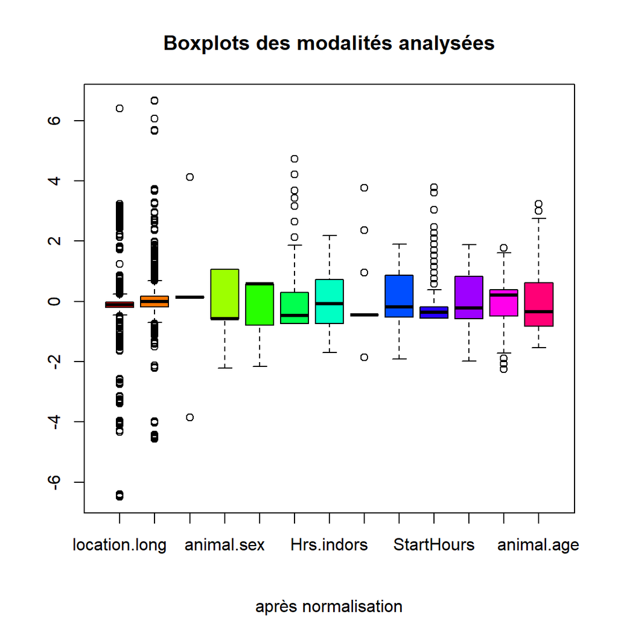

```r
CataDataQuantiNormZ = trimmedCatDataquanti %>%
  mutate(across(colnames(trimmedCatDataquanti), scale))
boxplot(CataDataQuantiNormZ, col = rainbow(length(CataDataQuantiNormZ)))
title(main = "Boxplots des modalités analysées", sub = "après normalisation")
```

Exportation des données normalisées

```r
write.csv(CataDataQuantiNormZ, "../data/OutCatdataQuantiNormZ.csv")
```